# 딥러닝

# 딥러닝의 발전

## 딥러닝의 문제점

- 앞에서 학습한 바와 같이 기본 인공 신경망은 입력에서 출력으로 가중치를 업데이트하면서 활성화 함수를 통해 결과값을 가지고 왔습니다. 이렇게 앞에서 순서대로 신호를 전달하는 것을 순전파(foward)라고 하며 말 그대로 앞쪽에서 입력값을 전달해 보내는 방식이었습니다. 하지만 모델 피팅(fitting)에서 이야기했듯 한 번 순전파가 전달되고 출력값이 정확하지 않으면 다시 역(reverse)으로 즉 입력 방향으로 오차를 거꾸로 보내며 가중치를 업데이트 합니다. 여기서 결과에 영향을 많이 미친 노드(뉴런)에 더 많은 오차를 조정하는데 이때 다시 되돌아가는 신호를 오차 역전파(Error Backpropagation)라고 합니다. 한 번 돌아와서 학습을 완료하는 것을 1 에포트 주기라고 했으며 에포크를 늘릴 수록 가중치가 계속 업데이트(학습)되면서 점점 오차가 줄어나가게 됩니다.
- 딥러닝 알고리즘은 이런 간단한 피드포워딩 신경망(feed-forward neural network)부터 출발했습니다. 우리 뇌에 있는 뉴런들이 층층이 연결되어 있는 것을 모방한 것이었습니다. 하지만, 신경망의 층 수가 늘어나면서 경사감소 소멸(Gradient Descent Vanishing) 문제가 발생합니다. 경사감소소멸은 역전파(BP, back propagation)를 통해 신경망 내의 가중치들이 제대로 훈련이 되지 않아서 신경망 층이 늘어나면서 출력층의 정보가 역전 되는 과정에서 판별력이 소멸되는 문제가 발생하는 것입니다.
- 이 문제를 해결하기 위해서 신뢰심층망(DBN, deep belief network)과 SAE(Stacked Auto-Encoder) 등의 방법이 제안되었습니다. DBN과 SAE는 각 층의 가중치들을 우선 사전학습(pre-training)을 통해 어느 정도 정확하게 근접한 값으로 보정한 후에 다시 조정 튜닝(fine-tuning)과정을 통해 최종 가중치를 계산하는 방식들입니다.
- 이후 좀더 앞선 방식으로 컨볼루션 신경망(CNN, convolutional neural network)이 개발되었습니다. CNN은 GPU 발전과 더불어 컴퓨터 비전 딥러닝 분야 기술을 완전 정복한 오늘날 대표적인 딥러닝 모델이 되었습니다. 이후 CNN 구조를 개선한 AlexNet등 여러 딥러닝 알고리즘들이 지속적인 발전을 거듭하고 있습니다.

## CNN 모델

- 머신러닝 분야에서 CNN은 이미지 분류를 위해 많이 사용되어 특정 이미지를 CNN 모델에 입력하면 그 이미지가 강아지인지 고양이인지를 분류해내는 목적으로 사용되었습니다. 기존 피드포워딩 신경망의 경우 이미지 픽셀값들은 그대로 입력 받아 어떤 클래스에 속하는지 분류했습니다. 하지만 같은 강아지 이미지라도 약간 회전되어 있거나, 크기가 다르고 이미지 변형이 약간만 있어도 분류하는데 어려움을 겪었습니다. 이 경우 훈련데이터가 많이 필요했고, 그만큼 훈련 시간도 상당히 길어진다는 단점이 있었습니다. 그래서 이미지 픽셀값들을 그대로 입력 받는 것보다는 이미지를 대표할 수 있는 특성들을 도출해서 신경망에 추가하는 기술을 등장하게 됩니다. 어떤 특성을 도출해야 분류에 도움이 될지는 사용자의 판단에 따라 결정됩니다. 예를 들어 사과와 배를 분류하는 문제라면 색에 대한 특성, 길이에 대한 특성, 형태에 대한 특성들을 도출하는 식이었습니다. CNN은 이 특성 도출 과정을 자동화했습니다. 기본 구조를 먼저 살펴보겠습니다.

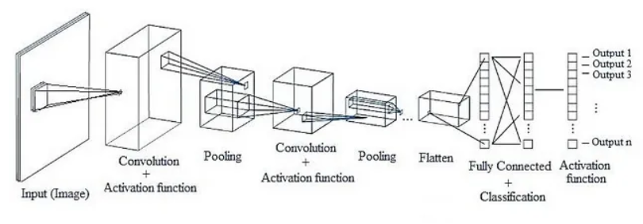

### 컴볼루셔널 계층(Convolutional Layer)

> - 원본 이미지에 컨벌루션(Convolution) 연산을 수행하는 레이어로 필터의 개수, 필터의 크기, 패딩 방법을 정의합니다. 여기에 입력 이미지와 출력 이미지의 해상도가 달라지는 것을 방지하기 위해서 패딩(Padding)을 입력 이미지에 적용합니다.
> - 패딩 (Padding) : 입력 이미지 매트릭스의 상하, 좌우로 '0'을 추가하는 것을 패딩이라고 합니다.
> - 필터 (Filter) : 일반적으로 3X3, 5X5 필터를 사용합니다. 보통 필터의 개수는 레이어가 추가될 때마다 두배로 늘어납니다.
> - Activation Layer : 0보다 작은 값은 0으로 만들어서 사물의 경계선 만을 특징으로 선택합니다. 보통 ReLU 함수를 사용합니다.
- 컨볼루셔널 연산(convolutional operation)  
  컨볼루셔널 계층에서 수행하는 연산은 다음과 같은 2단계 수학 연산입니다.
  > - 1단계 : 컴볼루셔널 필터 및 입력 행렬의 슬라이스 등 요소별 곱셈 (입력 행렬의 슬라이스는 컨벌루셔널 필터와 순위 및 크기가 동일함)
  > - 2단계 : 곱셈의 결과로 얻어지는 행렬 내 모든 값의 합계

### 폴링 계층(Pooling Layer)

- 레이어가 추가될 때마다 필터 개수는 두 배로 늘리고 해상도는 반으로 줄이도록 설계한 계층입니다. 사물의 특징을 보존하면서 해상도를 줄이는 역할을 수행합니다. 맥스풀링(Max pooling)은 필터값이 없는 윈도우가 이미지 위에서 이동하면서 내부의 값들 중에 최대값을 선택하는 방식입니다.

### 완전연결측

- 완전연결측(FC Layer : Fully Connected Layer)은 덴스(Dense)하게 연결되어있다는 뜻이며 히든 레이어(Hidden layer)로서 모든 유닛이 빠짐없이 연결되어 있습니다.

### 출력층

- 출력층(Output Layer)은 강아지 또는 고양이의 0과 1의 분류 문제이기 때문에 시그모이드 함수를 사용합니다.

### 드롭아웃

- 드롭아웃(Dropout)은 대표적인 과대 적합을 방지하기 위한 규제 방법입니다. 주어진 확률로 임의로 유닛(unit)을 선택해서 중지합니다. 예를 들어 레이어의 유닛 수가 32개이고 Dropout의 확률이 0.25이면 입력이 들어올 때마다 8개의 유닛을 랜덤하게 선택해 규제합니다. 훈련 과정에서만 적용해야 합니다.

## CNN 모델링 단계 요약

> 1. CONV = 3X3 filter, padding = 'same', activation='relu'로 정의
> 2. CONV 32 X2 : 32개의 필터로 CONV를 두 번 수행
> 3. POOL = 2X2 window, dropout = 0.25로 정의
> 4. POOL = POOL을 수행한다. 1/4 확률로 랜덤하게 유닛을 규제
> 5. CONV 64 X2 : 64개의 필터로 CONV 두번 수행
> 6. POOL = POOL을 수행한다. 1/4 확률로 랜덤하게 유닛을 규제
> 7. FC = activation='relu', 3. dropout = 0.25로 정의
> 8. FC 512 : 512개의 units로 뉴럴 네트워크 레이어를 정의. 1/4 확률로 랜덤하게 유닛을 규제
> 9. OUTPUT : 시그모이드(Sigmoid)로 출력 레이어를 정의

## 필터 모델 개념 실습

- 필터 개념은 네이버 스노우, 카카오톡 치즈등 최근 스마트폰 카메라 앱을 사용했다면 금방 이해할 수 있습니다. 필터 기술은 이미지 처리뿐만 아니라 음성 인식등 여러 신호처리(Signal Processing) 분야에서 필수 기술로 사용됩니다. 보통 노이즈를 제거하는 등 원본 자료를 가공할 때 사용합니다. CNN의 C의 의미인 컨벌루젼(Convolution) 역시 신호처리 기본 함수로 자주 사용됩니다.
- 필터 모델 확인을 위해 사이킷이미지(Scikit-image)로 실습해보겠습니다. 사이킷 이미지는 파이썬 오픈 소스 이미지 라이브러리입니다. 세분화, 기사학적 변형, 색 공간 조작, 분석, 필터링, 형태학, 형상 감지 등의 알고리즘기능이 포함되어 있으며 넘파이(NumPy) 및 사이파이(SciPy)와 상호 운용되도록 설계되어 있습니다. 사이킷이미지에는 많은 이미지를 제공하고 있으니 변경하여 필터 모델을 만들어 봅시다.

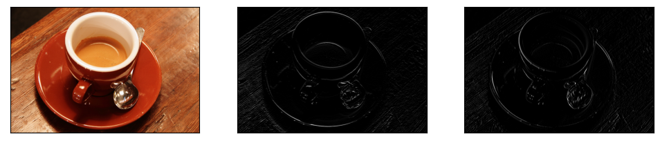

```python
import numpy as np
import matplotlib.pylab as plt
from skimage.data import coffee
from skimage.filters import sobel_h, sobel_v
from skimage.color import rgb2gray

# 커피 이미지를 INPUT
image = coffee()
grey_image = rgb2gray(image)

# CONV
edge_h = sobel_h(grey_image)
edge_v = sobel_v(grey_image)

# ReLU
edge_h = np.where(edge_h < 0, 0, edge_h)
edge_v = np.where(edge_v < 0, 0, edge_v)
plt.figure(figsize=(12, 4))
plt.subplot(1, 3, 1)
plt.imshow(image)
plt.xticks([])
plt.yticks([])
plt.subplot(1, 3, 2)
plt.imshow(edge_h, cmap = plt.cm.gray)
plt.xticks([])
plt.yticks([])
plt.subplot(1, 3, 3)
plt.imshow(edge_v, cmap=plt.cm.gray)
plt.xticks([])
plt.yticks([])
plt.show()
```

# 텐서플로 CNN 모델 만들기

## 데이터 준비 및 분할

- MNIST 데이터셋 다운로드하고 준비합시다.

```python
from tensorflow.keras import datasets, layers, models
(train_images, train_labels), (test_images, test_labels) = datasets.mnist.load_data()

train_images = train_images.reshape((60000, 28, 28, 1))
test_images = test_images.reshape((10000, 28, 28, 1))

# 필섹 값을 0~1 사이로 정규화합니다.
train_images, test_images = train_images / 255.0 , test_images / 255.0
```

## CNN 모델링

- 컨볼루션 모델은 보통 6계층으로 구성되는데 Conv2D와 MaxPooling2D 층을 쌓는 일반적인 패턴으로 합성곱 층을 정의합니다. CNN은 이미지 높이, 이미지 너비, 컬러 채널 크기의 텐서(tensor)로 입력으로 받습니다. MNIST 데이터는 (흑백 이미지이기 때문에) 컬러 채널(channel)이 하나지만 컬러 이미지는 (R, G, B) 세 개의 채널을 가집니다. 이 예에서는 MNIST 이미지 포맷인 (28, 28, 1) 크기의 입력을 처리하는 CNN을 정의합니다. 이 값을 첫 번째 층의 input_shape 매개변수로 전달합니다.

```python
model = models.Sequential()
model.add(layers.Conv2D(32, (3, 3), activation='relu', input_shape=(28, 28, 1)))
model.add(layers.MaxPool2D((2, 2)))
model.add(layers.Conv2D(64, (3, 3), activation='relu'))
model.add(layers.MaxPool2D((2, 2)))
model.add(layers.Conv2D(64, (3, 3), activation='relu'))
```

- 초기 구성층  
  Conv2D와 MaxPooling2D 층의 출력은 (높이, 너비, 채널) 크기의 3D 텐서로 높이와 너비 차원은 네트워크가 깊어질수록 감소하는 경향을 가집니다. Conv2D 층에서 출력 채널의 수는 첫 번째 매개변수에 의해 결정됩니다. (예를 들면, 32 또는 64). 일반적으로 높이와 너비가 감소함에 따라 (계산 비용 측면에서) Conv2D 층의 출력 채널을 증가 시킵니다.

```python
model.summary()
```

```
Model: "sequential_1"
_________________________________________________________________
 Layer (type)                Output Shape              Param #
=================================================================
 conv2d (Conv2D)             (None, 26, 26, 32)        320

 max_pooling2d (MaxPooling2D  (None, 13, 13, 32)       0
 )

 conv2d_1 (Conv2D)           (None, 11, 11, 64)        18496

 max_pooling2d_1 (MaxPooling  (None, 5, 5, 64)         0
 2D)

 conv2d_2 (Conv2D)           (None, 3, 3, 64)          36928

=================================================================
Total params: 55,744
Trainable params: 55,744
Non-trainable params: 0
_________________________________________________________________
```

- 최종 구성층  
  마지막에 Dense 층 추가하여 모델을 완성하고 합성곱 층의 출력 텐서(크기 (3, 3, 64))를 하나 이상의 Dense 층에 추가하여 분류를 수행해봅니다. Dense 층은 벡터(!D)를 입력으로 받는데 현재 출력은 3D 텐서가 됩니다. 먼저 3D 출력은 1D로 확장하고 다음 하나 이상의 Dense 층을 그 위에 추가합니다. MNIST 데이터는 10개의 클래스가 있으므로 마지막에 Dense 층에 10개의 출력과 소프트맥스 활성화 함수를 사용합니다.

```python
model.add(layers.Flatten())
model.add(layers.Dense(64, activation='relu'))
model.add(layers.Dense(10, activation='softmax'))
```

- 최종 모델의 구조를 확인해 보겠습니다. 아래에서 볼 수 있듯이 두 개의 Dense 층을 통과하기 전에 (3, 3, 64) 출력을 (576) 크기의 벡터로 확장했습니다.

```python
model.summary()
```

```
Model: "sequential_1"
_________________________________________________________________
 Layer (type)                Output Shape              Param #
=================================================================
 conv2d (Conv2D)             (None, 26, 26, 32)        320

 max_pooling2d (MaxPooling2D  (None, 13, 13, 32)       0
 )

 conv2d_1 (Conv2D)           (None, 11, 11, 64)        18496

 max_pooling2d_1 (MaxPooling  (None, 5, 5, 64)         0
 2D)

 conv2d_2 (Conv2D)           (None, 3, 3, 64)          36928

 flatten_5 (Flatten)         (None, 576)               0

 dense_2 (Dense)             (None, 64)                36928

 dense_3 (Dense)             (None, 10)                650

=================================================================
Total params: 93,322
Trainable params: 93,322
Non-trainable params: 0
_________________________________________________________________
```

## 모델 정의

- 정의된 모델을 학습하기 앞서 컴파일합니다. 모델의 학습 중에 역전파를 통한 가중치 최적화를 위한 기울기 방향에 대한 경사하강을 위한 방법으로 'Adam'을 사용합니다. 비용함수로 다중 분류인 'sparse_categorical_crossentropy'를 사용하며 모델 평가를 위한 평가 지표로 'accuracy'를 설정합니다.

```python
model.compile(optimizer='adam', loss='sparse_categorical_crossentropy', metrics=['accuracy'])
```

## 모델 학습 및 피팅

```python
# 에포크 횟수가 반복될수록 손실함수는 줄어들고 정확도는 향상되고 있습니다.
model.fit(train_images, train_labels, epochs=5)
```

[output not shown]

```
<keras.callbacks.History at 0x1f0b62d0ac0>
```

## 모델 평가

```python
# 최종 인식 정확도는 98.9%로 나타났습니다.
test_loss, test_acc = model.evaluate(test_images, test_labels, verbose=2)
print('test_acc:', test_acc)
```

```
313/313 - 1s - loss: 0.0321 - accuracy: 0.9896 - 682ms/epoch - 2ms/step
test_acc: 0.9896000027656555
```

## 시각화 평가

[figure not shown]

```python
import matplotlib as mpl
import matplotlib.pylab as plt

plt.figure(figsize=(8, 4))
plt.subplot(1, 2, 1)
plt.plot(hist.history['loss'])
plt.title("loss")
plt.subplot(1, 2, 2)

plt.title("accuracy")
plt.plot(hist.history['accuracy'], 'b-', label="training")

# plt.plot(model.history['val_accuracy'], 'r:', label="validation")
plt.legend()
plt.tight_layout()
plt.show()
```

# 텐서플로 Estimator

- 텐스폴르 Estimator(tf.estimator)는 사이킷런과 비슷한 고수준 API입니다. 머신러닝에 기본인 모델 학습, 평가, 예측, 배포 기능을 제공합니다. 사이킷런 API와 호환을 통해 파이썬의 인기 있는 라이브러리를 사용할 수 있으며 구글 직원들도 많이 사용하고 있다고 합니다. 텐서플로 2.0에서 케라스 API는 배우기 쉬운 API이므로 새로 시작하는 경우 케라스로 시작하는 것을 추천합니다.
- Estimators를 사용하여 텐서플로에서 아이리스(Iris) 분류 예측 문제를 실습합니다.  
  |변수||설명||변수구분| |:--:||:--:||:--:| |sepal length||꽃받침의 길이||| |sepal width||꽃받침의 너비||| |petal length||꽃잎의 길이||| |petal width||꽃잎의 너비||| |Species||꽃의 종류||Setosa, versicolor, virginica 3종|

## 라이브러리 및 데이터 불러오기

```python
from __future__ import absolute_import, division, print_function, unicode_literals
import tensorflow as tf
import pandas as pd

CSV_COLUMN_NAMES = ['SepalLength', 'SepalWidth', 'PetalLength', 'PetalWidth', 'Species']
SPECIES = ['Setosa', 'Versicolor', 'Virginica']
train_path = tf.keras.utils.get_file("iris_Training.csv", "https://storage.googleapis.com/download.tensorflow.org/data/iris_training.csv")
test_path = tf.keras.utils.get_file("iris_test.csv", "https://storage.googleapis.com/download.tensorflow.org/data/iris_test.csv")

train = pd.read_csv(train_path, names=CSV_COLUMN_NAMES, header=0)
test = pd.read_csv(test_path, names=CSV_COLUMN_NAMES, header=0)
```

## 데이터 보기

```python
train.head()
```

|  | SepalLength | SepalWidth | PetalLength | PetalWidth | Species |
| --- | --- | --- | --- | --- | --- |
| 0 | 6.4 | 2.8 | 5.6 | 2.2 | 2 |
| 1 | 5.0 | 2.3 | 3.3 | 1.0 | 1 |
| 2 | 4.9 | 2.5 | 4.5 | 1.7 | 2 |
| 3 | 4.9 | 3.1 | 1.5 | 0.1 | 0 |
| 4 | 5.7 | 3.8 | 1.7 | 0.3 | 0 |

## 데이터 분할

```python
train_y = train.pop('Species')
test_y = test.pop('Species')
train.head()
```

|  | SepalLength | SepalWidth | PetalLength | PetalWidth |
| --- | --- | --- | --- | --- |
| 0 | 6.4 | 2.8 | 5.6 | 2.2 |
| 1 | 5.0 | 2.3 | 3.3 | 1.0 |
| 2 | 4.9 | 2.5 | 4.5 | 1.7 |
| 3 | 4.9 | 3.1 | 1.5 | 0.1 |
| 4 | 5.7 | 3.8 | 1.7 | 0.3 |

## 데이터 입력 기능 모듈 생성

```python
def input_evaluation_set():
    features = {'SepalLength': np.array[(5.4, 5.0)],
               'SepalWidth': np.array([2.8, 2.3]),
               'PetalLength': np.array([5.6, 3.3]),
               'PetalWidth': np.array([2.2, 1.0])}
    labels = np.array([2, 1])
    return features, labels

def input_fn(features, labels, training=True, batch_size = 256):
    """An input function for training or evaluating"""
    # Convert the inputs to a Dataset
    dataset = tf.data.Dataset.from_tensor_slices((dict(features), labels))

    # Shuffle and repeat if you are in training mode
    if training:
        dataset = dataset.shuffle(1000).repeat()

    return dataset.batch(batch_size)

# Feature columns describe how to use the input
my_feature_columns = []
for key in train.keys():
    my_feature_columns.append(tf.feature_column.numeric_column(key=key))
```

## DNN 모델 생성

```python
# 30, 10 유닛으로 구성된 2개 계층 DNN 생성
classifier = tf.estimator.DNNClassifier(
feature_columns=my_feature_columns,
hidden_units=[30, 10],
# 3개 클래스다중분류
n_classes=3)
```

[output not shown]